# T-Test Materials

Author

Brier Gallihugh, M.S.

Published

July 11, 2024

## An Introduction to T-tests

## Assumptions of T-tests

### Normality of Residuals

```r
library(tidyverse)

data <- starwars %>%
  filter(sex == "male" | sex == "female")

model <- lm(height ~ sex, data = data)

residuals <- data.frame(res = residuals(model))

problem <- residuals %>% filter(res > 2.5 | res < -2.5)

nrow(problem)/nrow(data)
```

**1**

Filtering for male the female using the `filter()` function

**2**

Running a linear regression (that is a t-test here) to get residuals

**3**

Calculate residuals for the observations

**4**

Find potentially problematic observations

```
[1] 0.8421053
```

#### Graphical Depiction of Normality of Residuals

```r
residual_graph <- ggplot(residuals,aes(x = res)) +
  geom_histogram(aes(y=after_stat(density))) +
  stat_function(fun = dnorm,
                args = list(mean = mean(residuals$res),
                            sd = sd(residuals$res)),
                col = "blue",
                linewidth = 1) +
  theme_classic()

print(residual_graph)
```

**1**

We are plotting the residuals here. We give ggplot a `geom` (i.e., histogram)

**2**

We also give some other arguments like a density distribution.

**3**

Here we are basically providing what is needed to draw a normal distribution given the data using the `stat_function()` function. The `col` and `linewidth` arguments simply change the colr and size of the normal curve. The `theme_classic()` just changes some aesthetic things. I personally prefer this theme for all ggplot2 graphs

**4**

`print` will show us the graph output

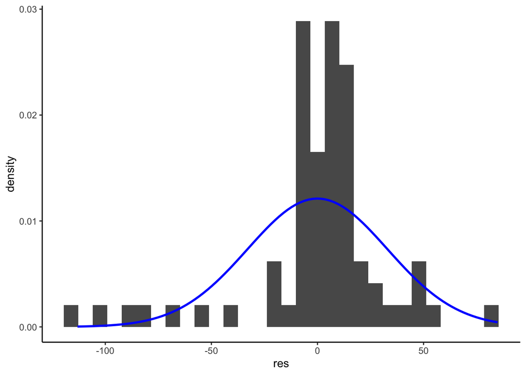

#### Statistical Depiction of Normality of Residuals

We can also test the assumption statistically using the `shapiro.test()` function here

```r
shapiro.test(residuals$res)
```

```
    Shapiro-Wilk normality test

data:  residuals$res
W = 0.84834, p-value = 5.13e-07
```

### Homogeneity of Variance

Homogeneity of variance is important even for a basic t-test. Below is how we might go about testing this assumption.

#### Graphical Depiction of Homogeneity of Variance

```r
variance_boxplot <- ggplot(data,aes(x = sex,
                               y = height)) +
  geom_boxplot() +
  theme_classic()

print(variance_boxplot)
```

**1**

Graphically we can represent this as a boxplot with the group variable as the `x` and the outcome as the `y`. We see this here

**2**

We again provide a `geom` for ggplot2 to use and provide a `theme()` choice here

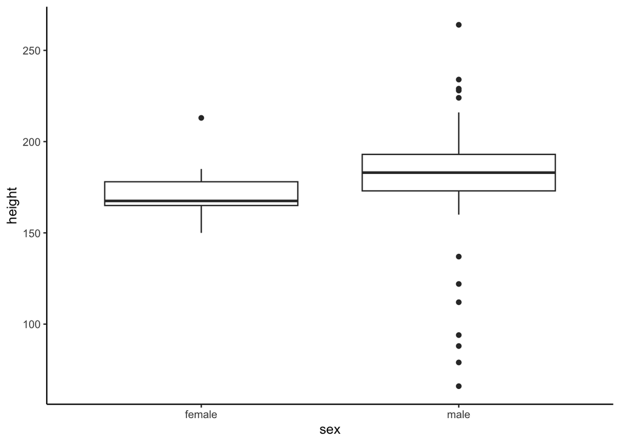

#### Statistical Depiction of Homogeneity of Variance

We can also test the assumption using the Bartlett test. This can be shown below

```r
bartlett.test(height ~ sex,data)
```

```
    Bartlett test of homogeneity of variances

data:  height by sex
Bartlett's K-squared = 9.6316, df = 1, p-value = 0.001913
```

## Running a T-test

```r
t.test(height ~ sex, data = data)
```

**1**

The `t.test()` function will take a DV and IV argument as well as the dataframe used. We can see this here

```
    Welch Two Sample t-test

data:  height by sex
t = -1.1817, df = 48.471, p-value = 0.2431
alternative hypothesis: true difference in means between group female and group male is not equal to 0
95 percent confidence interval:
 -20.396341   5.293584
sample estimates:
mean in group female   mean in group male
            171.5714             179.1228
```